# Auswertung eines Datensatzes

- Gesamten Code zeigen
- Gesamten Code verbergen
- Quellcode anzeigen

Arbeitsblatt 2 – Principles of Data Visualization, Herbstsemester 2026

Autor:in

Elio Schmid

Veröffentlichungsdatum

06.10.2026

Geändert

19.10.2026

**Code anzeigen**

```r
library(tidyverse)
```

**Autor:** Elio Schmid, FH Graubünden, MSc Data Visualization  
**Dozentin:** PD Dr. rer. nat. Helena Jambor  
**Ort, Datum:** Bern, 06.10.2026

**Hinweis**

Dieses Dokument ist in Bearbeitung und wird laufend ergänzt. Das Datum der letzten Änderung steht im Titelblock oben.

# 1 Aufgabe 2 Teil 2

## 1.1 Euere eigenen Analysen und Daten zu Gesundheit und Nachhaltigkeit

Anfang Oktober habe ich einen Artikel von SRF über den Gletscherschwund in der Schweiz gelesen. Der Artikel ist hier [verlinkt.](https://www.srf.ch/wissen/klimawandel/eisverlust-2026-massive-gletscherschmelze-so-viel-eis-verschwand-im-hitzesommer) Darin wird auf Daten von Glamos - Glacier Monitoring in Switzerland verwiesen. Das Thema interessiert mich insofern, als dass ich relativ viel in den Bergen unterwegs bin. Auf der Website von Glamos finden wir Daten zu Bestand, Längenänderung, Massenbilanz, Volumenänderung sowie Szenarien. Die Daten unterscheiden sich in Stichtagsmessungen und Zeitreihen. Es werden Flächen-, Ausdehnungs- und Geodaten erfasst. In meiner Analyse möchte ich mich auf die Volumenänderung konzentrieren. Ich kann mir aber vorstellen auch Bestandesdaten einfliessen zu lassen oder Längenänderungen. Dies werde ich im Zuge der Auswertung wohl feststellen. Der Datensatz, den ich analysieren möchte, lässt sich [hier](https://doi.glamos.ch/data/volumechange/volumechange_2025_r2025.html) einsehen.

Nach der ersten Auseinandersetzung mit dem Datensatz, muss ich festhalten, dass es doch schwerer ist diesen auszuwerten als vorerst angenommen. Die Beobachtungen überschneiden sich und Aussagen zu Entwicklungen über eine Zeitdistanz sind anspruchsvoll. Sie können höchstens für einen gewissen Teil der Gletscher erfolgen.

# 2 Aufgabe 3

## 2.1 Datensatz

Der Datensatz beinhaltet die Daten der Volumenänderung, mittlere Dickenänderungen und die jährliche geodätische Massenbilanz. Die Zahlen werden aus dem Vergleich von digitalen Höhenmodellen basierend auf Luftbildern ermittelt. Dies ermöglicht die Berechnung von Volumenänderungen der Gletscher über Jahre bis Jahrzehnte. Änderungen des Gletschervolumens wurden in geodätische Massenbilanzen umgerechnet, unter der Annahme einer Dichte von 850 kg/m³. Der Datensatz enthält alle verfügbaren Beobachtungen bis heute für die wichtigsten Schweizer Gletscher und wird als CSV-Datei geliefert.

Quelle: GLAMOS (2025). Swiss Glacier Volume Change, release 2025, Glacier Monitoring Switzerland, doi:10.18750/volumechange.2025.r2025 (Lizenz CC BY 4.0).

Der Datensatz enthält 16 Variablen und 19’017 Beobachtungen. Eine Beobachtung (Zeile) ist ein Gletscher in einem Zeitfenster zwischen zwei Messungen. Pro Gletscher liegen im Median 9 Messperioden vor (maximal 205) bei im Median 5 Messterminen, und die Zeitfenster überlappen sich. Folgende Variablen sind vorhanden:

Variablen des Datensatzes mit Einheit und Bedeutung.

| Variablenname | Einheit | Bedeutung |
| --- | --- | --- |
| SGI-ID | – | Kennnummer im Schweizerischen Gletscherinventar |
| Name | – | Name des Gletschers |
| source_start | – | Datenquelle am Start der Periode (Kürzel wie `kp25`, `dhm25-l1`, `sa3d-2018`; eine Legende ist auf der Datensatzseite nicht beschrieben) |
| source_end | – | Datenquelle am Ende der Periode |
| date_start | yyyymmdd | Startdatum, teilweise mit unbekannten Anteilen (99 = Monat bzw. Tag unbekannt) |
| date_end | yyyymmdd | Enddatum, teilweise mit unbekannten Anteilen (99) |
| A_start | km² | Gletscherfläche am Start der Periode |
| outline_start | yyyy | Jahr des Gletscherumrisses, auf dem die Startfläche beruht |
| A_end | km² | Gletscherfläche am Ende der Periode |
| outline_end | yyyy | Jahr des Gletscherumrisses, auf dem die Endfläche beruht |
| dV | km³ | Volumenänderung des **Eises** über die Periode (negativ = Verlust) |
| dh_mean | m | Mittlere Änderung der Eisdicke über die Gletscherfläche |
| Bgeod | m w.e. a⁻¹ | Mittlere jährliche **Massenbilanz** in Metern Wasseräquivalent pro Jahr (negativ = Verlust). Bei −0.65 fehlt pro Jahr eine Wasserschicht von rund 65 cm über der ganzen Gletscherfläche. |
| sigma | m w.e. | Unsicherheit der Massenbilanz (Einheit wie in der Datei angegeben) |
| covered | % | Anteil der Gletscherfläche, für den Höhendaten vorlagen. Der Rest muss geschätzt werden. |
| rho_dv | kg/m³ | Dichte, mit der Eisvolumen in Wassermasse umgerechnet wird. Der Wert ist überall 850. |

Für die Auswertung sind vor allem die Gletscher-ID (`SGI-ID`), die Gletscherfläche (Start/Ende), die Volumenänderung (`dV`), die Massenbilanz (`Bgeod`) und die Messzeitpunkte (`date_start`, `date_end`) interessant. Die Massenbilanz ist auf die Gletscherfläche bezogen und lässt sich deshalb zwischen kleinen und grossen Gletschern direkt vergleichen. Die Volumenänderung hängt dagegen stark von der Gletschergrösse ab.

## 2.2 Daten einlesen

Die Datei enthält 6 Zeilen Metadaten, die Kopfzeile (Zeile 7) und eine Einheitenzeile (Zeile 8). Die Daten beginnen erst in Zeile 9.

**Code anzeigen**

```r
theme_set(theme_minimal(base_size = 12))

pfad <- "volumechange.csv"   # ggf. anpassen, z. B. "daten/volumechange.csv"

zeilen <- read_lines(pfad)
kopf   <- str_trim(strsplit(zeilen[7], ",")[[1]])

roh <- read_csv(
  I(paste(zeilen[-(1:8)], collapse = "\n")),
  col_names = kopf,
  col_types = cols(
    .default     = col_double(),
    `SGI-ID`     = col_character(),
    source_start = col_character(),
    source_end   = col_character(),
    date_start   = col_character(),   # Format yyyymmdd, teils mit 99/00
    date_end     = col_character(),
    Name         = col_character()
  ),
  trim_ws = TRUE
)

glimpse(roh)
```

```
Rows: 19,017
Columns: 16
$ `SGI-ID`      <chr> "A10g-02", "A10g-02", "A10g-02", "A10g-02", "A10g-02", "…
$ source_start  <chr> "dhm25-l1", "dhm25-l1", "dhm25-l1", "dhm25-l1", "sa3d-20…
$ source_end    <chr> "sa3d-2018", "ss3d-r2024", "sa3d-2022", "is-stand", "ss3…
$ date_start    <chr> "19919999", "19919999", "19919999", "19919999", "2014999…
$ date_end      <chr> "20149999", "20200821", "20219999", "20220715", "2020082…
$ A_start       <dbl> 0.5900, 0.5900, 0.5900, 0.5900, 0.3075, 0.3075, 0.0392, …
$ outline_start <dbl> 1973, 1973, 1973, 1973, 2014, 2014, 1973, 1973, 1973, 19…
$ A_end         <dbl> 0.3075, 0.2073, 0.2073, 0.2073, 0.2073, 0.2073, 0.0150, …
$ outline_end   <dbl> 2014, 2022, 2022, 2022, 2022, 2022, 2014, 2014, 2014, 20…
$ dV            <dbl> -0.010135, -0.012218, -0.010129, -0.013612, -0.002082, -…
$ dh_mean       <dbl> -17.140, -20.691, -17.153, -23.052, -6.763, -10.013, -6.…
$ Bgeod         <dbl> -0.835, -0.898, -0.720, -0.936, -1.146, -1.272, -0.287, …
$ sigma         <dbl> 0.152, 0.167, 0.123, 0.167, 0.201, 0.324, 0.276, 0.249, …
$ covered       <dbl> 100.0, 100.0, 100.0, 100.0, 100.0, 100.0, 100.0, 100.0, …
$ rho_dv        <dbl> 850, 850, 850, 850, 850, 850, 850, 850, 850, 850, 850, 8…
$ Name          <chr> "Seegletscher", "Seegletscher", "Seegletscher", "Seeglet…
```

## 2.3 Bereinigung

Folgende Anpassungen wurden vorgenommen:

- **Datum:** Bei vielen Messungen sind Monat und Tag unbekannt (Code 99 oder 00). Das Jahr bleibt gültig, der Monat wird auf August geschätzt, und `datum_exakt_start` bzw. `datum_exakt_end` markieren die Schätzungen. Daraus entstehen die Dauer der Periode und das mittlere Jahr.
- **Fläche:** Der Wert 0 steht für «nicht kartiert» und wird zu einem fehlenden Wert (`NA`).
- **Gruppierungen:** `sgi_gruppe` (erster Buchstabe der SGI-ID) und `groessenklasse` (Fläche am Start) erleichtern Vergleiche. Was die Buchstaben der SGI-ID genau bedeuten, habe ich nicht geprüft.
- **Entfernt:** `rho_dv` (überall 850).
- **Mehrfachzählung:** Weil sich die Zeitfenster eines Gletschers überlappen, enthält `gl_lang` pro Gletscher nur die längste Messperiode.

**Code anzeigen**

```r
# Datum yyyymmdd: Monat/Tag 99 oder 00 = unbekannt -> Schätzung 1. August
parse_datum <- function(x) {
  jahr <- str_sub(x, 1, 4)
  mon  <- str_sub(x, 5, 6)
  tag  <- str_sub(x, 7, 8)
  unbekannt <- mon %in% c("99", "00")
  mon[unbekannt] <- "08"
  tag[unbekannt | tag %in% c("00", "99")] <- "01"
  ymd(paste0(jahr, mon, tag))
}

gl <- roh |>
  rename(
    sgi_id         = `SGI-ID`,
    name           = Name,
    area_start_km2 = A_start,
    area_end_km2   = A_end,
    dv_km3         = dV,
    dh_mean_m      = dh_mean,
    bgeod_mwe_a    = Bgeod,
    sigma_mwe      = sigma,
    covered_pct    = covered
  ) |>
  mutate(
    # Datum
    datum_exakt_start = !str_sub(date_start, 5, 6) %in% c("99", "00"),
    datum_exakt_end   = !str_sub(date_end,   5, 6) %in% c("99", "00"),
    dt_start      = parse_datum(date_start),
    dt_end        = parse_datum(date_end),
    jahr_start    = year(dt_start),
    jahr_end      = year(dt_end),
    jahr_mitte    = (jahr_start + jahr_end) / 2,
    periode_jahre = as.numeric(dt_end - dt_start) / 365.25,
    # Fläche 0 = nicht kartiert -> fehlender Wert
    area_start_km2 = na_if(area_start_km2, 0),
    area_end_km2   = na_if(area_end_km2, 0),
    # Gruppierungen
    sgi_gruppe  = str_sub(sgi_id, 1, 1),
    groessenklasse = cut(
      area_start_km2,
      breaks = c(0, 0.1, 0.5, 2, 10, Inf),
      labels = c("<0.1", "0.1-0.5", "0.5-2", "2-10", ">10")
    ),
    massenzunahme = bgeod_mwe_a > 0,
    signifikant   = abs(bgeod_mwe_a) > 2 * sigma_mwe
  ) |>
  select(-rho_dv, -date_start, -date_end) |>   # rho_dv ist überall 850
  group_by(sgi_id) |>
  mutate(n_perioden = n()) |>
  ungroup()

# Pro Gletscher nur die längste Messperiode (vermeidet Mehrfachzählung)
gl_lang <- gl |>
  group_by(sgi_id) |>
  slice_max(periode_jahre, n = 1, with_ties = FALSE) |>
  ungroup()
```

## 2.4 Datenqualität

**Code anzeigen**

```r
# Fehlende Werte je Spalte
gl |>
  summarise(across(everything(), ~ sum(is.na(.x)))) |>
  pivot_longer(everything(), names_to = "variable", values_to = "n_na") |>
  filter(n_na > 0)
```

```
# A tibble: 3 × 2
  variable        n_na
  <chr>          <int>
1 area_start_km2    73
2 area_end_km2      11
3 groessenklasse    73
```

**Code anzeigen**

```r
# Anteil geschätzter Datumsangaben
gl |>
  summarise(
    start_geschaetzt = mean(!datum_exakt_start),
    ende_geschaetzt  = mean(!datum_exakt_end)
  )
```

```
# A tibble: 1 × 2
  start_geschaetzt ende_geschaetzt
             <dbl>           <dbl>
1            0.649           0.167
```

**Code anzeigen**

```r
# Gleiche Namen bei verschiedenen IDs
gl |>
  distinct(sgi_id, name) |>
  count(name) |>
  filter(n > 1)
```

```
# A tibble: 15 × 2
   name                     n
   <chr>                <int>
 1 Alphubel                 2
 2 Bas Glacier d'Arolla     2
 3 Breithorn                2
 4 Geisshorn                2
 5 Glacier de Moiry         2
 6 Grand Cornier            2
 7 Kleines Aletschhorn      2
 8 Olmenhorn                2
 9 Piz Pischa               2
10 Piz Vadret               2
11 Ritterpass               2
12 Sattelhorn               3
13 Schaligletscher E        2
14 Stockfirn W              2
15 Tournelon Blanc E        2
```

Fehlende Werte gibt es nur bei der Gletscherfläche: 73 Zeilen haben keine Startfläche und 11 keine Endfläche (im Original mit 0 angegeben). Beim Datum ist das Jahr immer bekannt, aber bei 64.9 % der Startdaten und 16.7 % der Enddaten fehlen Monat und Tag, sie sind deshalb auf August geschätzt. Bei kurzen Perioden wirkt sich das stärker auf die Dauer aus als bei Perioden von mehreren Jahrzehnten. 15 Gletschernamen kommen bei mehr als einer SGI-ID vor (Sattelhorn sogar bei dreien). Als Schlüssel verwende ich deshalb die SGI-ID und nicht den Namen.

## 2.5 Basiskennzahlen

**Code anzeigen**

```r
tribble(
  ~Kennzahl,                                      ~Wert,
  "Anzahl Messperioden (Zeilen)",                 format(nrow(gl), big.mark = "'"),
  "Anzahl Gletscher",                             format(n_distinct(gl$sgi_id), big.mark = "'"),
  "Messperioden pro Gletscher (Median)",          format(median(gl_lang$n_perioden)),
  "Zeitraum",                                     paste(min(gl$jahr_start), "bis", max(gl$jahr_end)),
  "Massenbilanz [m w.e. a⁻¹] (Median)",           format(round(median(gl_lang$bgeod_mwe_a), 2)),
  "Anteil Gletscher mit negativer Massenbilanz",  scales::percent(mean(gl_lang$bgeod_mwe_a < 0), accuracy = 0.1)
) |>
  knitr::kable()
```

| Kennzahl | Wert |
| --- | --- |
| Anzahl Messperioden (Zeilen) | 19’017 |
| Anzahl Gletscher | 1’438 |
| Messperioden pro Gletscher (Median) | 9 |
| Zeitraum | 1850 bis 2024 |
| Massenbilanz [m w.e. a⁻¹] (Median) | -0.49 |
| Anteil Gletscher mit negativer Massenbilanz | 99.3% |

**Code anzeigen**

```r
gl_lang |>
  select(area_start_km2, dv_km3, dh_mean_m, bgeod_mwe_a, sigma_mwe, periode_jahre) |>
  summary()
```

```
 area_start_km2        dv_km3             dh_mean_m        bgeod_mwe_a
 Min.   : 0.0029   Min.   :-6.1451090   Min.   :-83.713   Min.   :-2.1130
 1st Qu.: 0.0717   1st Qu.:-0.0106270   1st Qu.:-22.355   1st Qu.:-0.6857
 Median : 0.1908   Median :-0.0029850   Median :-16.447   Median :-0.4920
 Mean   : 0.9501   Mean   :-0.0333257   Mean   :-16.951   Mean   :-0.5286
 3rd Qu.: 0.5208   3rd Qu.:-0.0007988   3rd Qu.: -9.892   3rd Qu.:-0.3272
 Max.   :92.1042   Max.   : 0.0003360   Max.   :  3.804   Max.   : 0.1490
 NAs    :16
   sigma_mwe      periode_jahre
 Min.   :0.0450   Min.   :  2.987
 1st Qu.:0.1490   1st Qu.: 36.030
 Median :0.2180   Median : 40.060
 Mean   :0.2623   Mean   : 41.833
 3rd Qu.:0.3360   3rd Qu.: 50.954
 Max.   :0.9940   Max.   :171.951
```

## 2.6 Deskriptive Statistik nach Gruppen

**Code anzeigen**

```r
gl_lang |>
  group_by(sgi_gruppe) |>
  summarise(
    n            = n(),
    median       = median(bgeod_mwe_a),
    mittel       = mean(bgeod_mwe_a),
    sd           = sd(bgeod_mwe_a),
    dv_summe_km3 = sum(dv_km3),
    .groups = "drop"
  ) |>
  knitr::kable(digits = 2)
```

Tabelle 1: Massenbilanz nach SGI-Hauptgruppe (längste Periode je Gletscher)

| sgi_gruppe | n | median | mittel | sd | dv_summe_km3 |
| --- | --- | --- | --- | --- | --- |
| A | 659 | -0.46 | -0.50 | 0.28 | -14.39 |
| B | 585 | -0.49 | -0.52 | 0.29 | -28.91 |
| C | 87 | -0.52 | -0.58 | 0.27 | -1.64 |
| E | 107 | -0.73 | -0.75 | 0.25 | -2.98 |

**Code anzeigen**

```r
gl_lang |>
  filter(!is.na(groessenklasse)) |>
  group_by(groessenklasse) |>
  summarise(
    n      = n(),
    median = median(bgeod_mwe_a),
    mittel = mean(bgeod_mwe_a),
    sd     = sd(bgeod_mwe_a),
    .groups = "drop"
  ) |>
  knitr::kable(digits = 2)
```

Tabelle 2: Massenbilanz nach Flächenklasse (längste Periode je Gletscher)

| groessenklasse | n | median | mittel | sd |
| --- | --- | --- | --- | --- |
| <0.1 | 455 | -0.34 | -0.40 | 0.30 |
| 0.1-0.5 | 598 | -0.51 | -0.54 | 0.25 |
| 0.5-2 | 254 | -0.64 | -0.66 | 0.25 |
| 2-10 | 92 | -0.61 | -0.66 | 0.29 |
| >10 | 23 | -0.44 | -0.51 | 0.24 |

## 2.7 Erste Übersicht

Erste einfache Grafiken zur Orientierung. Sie nutzen jeweils die längste Messperiode pro Gletscher (`gl_lang`).

### 2.7.1 Verteilung der Massenbilanz

**Code anzeigen**

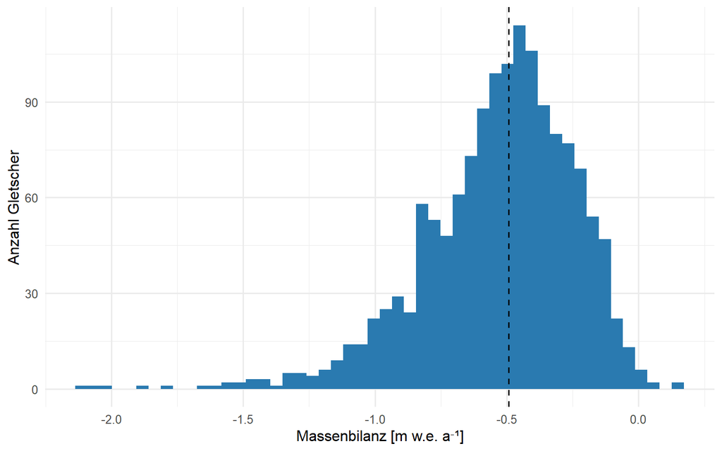

Abbildung 1: Verteilung der geodätischen Massenbilanz (längste Periode je Gletscher)

```r
ggplot(gl_lang, aes(bgeod_mwe_a)) +
  geom_histogram(bins = 50, fill = "#2a7ab0") +
  geom_vline(xintercept = median(gl_lang$bgeod_mwe_a), linetype = "dashed") +
  labs(x = "Massenbilanz [m w.e. a⁻¹]", y = "Anzahl Gletscher")
```

### 2.7.2 Gletschergrösse und Massenbilanz

**Code anzeigen**

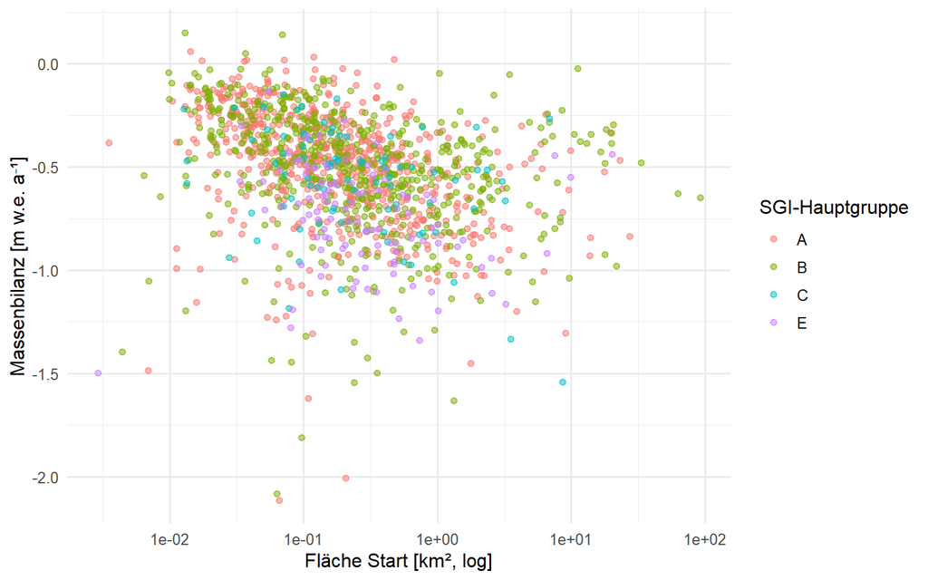

Abbildung 2: Gletscherfläche (Start) und Massenbilanz

```r
ggplot(gl_lang, aes(area_start_km2, bgeod_mwe_a, colour = sgi_gruppe)) +
  geom_point(alpha = 0.5) +
  scale_x_log10() +
  labs(x = "Fläche Start [km², log]", y = "Massenbilanz [m w.e. a⁻¹]",
       colour = "SGI-Hauptgruppe")
```

### 2.7.3 Massenbilanz nach Gruppen

**Code anzeigen**

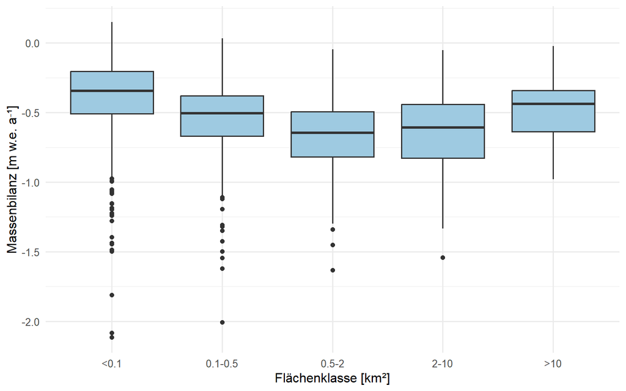

Abbildung 3: Massenbilanz nach Grössenklasse

```r
gl_lang |>
  filter(!is.na(groessenklasse)) |>
  ggplot(aes(groessenklasse, bgeod_mwe_a)) +
  geom_boxplot(fill = "#9ecae1") +
  labs(x = "Flächenklasse [km²]", y = "Massenbilanz [m w.e. a⁻¹]")
```

### 2.7.4 Grösste Volumenverluste

**Code anzeigen**

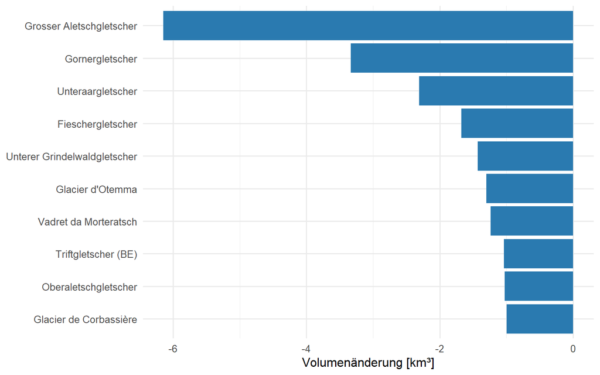

Abbildung 4: Die 10 Gletscher mit dem grössten Volumenverlust (längste Periode)

```r
gl_lang |>
  slice_min(dv_km3, n = 10) |>
  mutate(name = fct_reorder(name, -dv_km3)) |>
  ggplot(aes(dv_km3, name)) +
  geom_col(fill = "#2a7ab0") +
  labs(x = "Volumenänderung [km³]", y = NULL)
```

## 2.8 Einfache Zusammenhangsprüfung

**Code anzeigen**

```r
# Fläche vs. Massenbilanz (Rangkorrelation, da Fläche stark schief verteilt)
cor.test(gl_lang$area_start_km2, gl_lang$bgeod_mwe_a,
         method = "spearman", exact = FALSE)
```

```
    Spearman's rank correlation rho

data:  gl_lang$area_start_km2 and gl_lang$bgeod_mwe_a
S = 684272339, p-value < 2.2e-16
alternative hypothesis: true rho is not equal to 0
sample estimates:
      rho
-0.427847
```

**Code anzeigen**

```r
# Unterscheiden sich die SGI-Gruppen?
kruskal.test(bgeod_mwe_a ~ sgi_gruppe, data = gl_lang)
```

```
    Kruskal-Wallis rank sum test

data:  bgeod_mwe_a by sgi_gruppe
Kruskal-Wallis chi-squared = 87.088, df = 3, p-value < 2.2e-16
```

## 2.9 Visualisierungsansätze

Nach der ersten Übersicht habe ich vier Fragen an die Daten formuliert und für jede einen Ansatz entwickelt. Jeder Ansatz ist nach demselben Raster dokumentiert: Frage, analytische Aufgabe, Diagrammtyp mit Marks und Channels, was funktioniert hat und was ich verworfen habe. Die Grafiken sind bewusst einfach und in Graustufen bzw. mit einer einzelnen Akzentfarbe gehalten, weil sie ein explorativer Zwischenschritt sind.

**Code anzeigen**

```r
n_total <- n_distinct(gl$sgi_id)

# Grösste je erfasste Fläche pro Gletscher, damit die Klasse über alle Perioden gleich bleibt
klassen <- gl |>
  group_by(sgi_id) |>
  summarise(flaeche_max = max(c(area_start_km2, area_end_km2), na.rm = TRUE), .groups = "drop") |>
  mutate(klasse = cut(
    flaeche_max,
    breaks = c(0, 0.1, 0.5, 2, Inf),
    labels = c("< 0.1 km²", "0.1 – 0.5 km²", "0.5 – 2 km²", "> 2 km²")
  ))
```

### 2.9.1 Ansatz 1: Zeitverlauf der Massenbilanz nach Grössenklasse

**Frage:** Wie hat sich die Massenbilanz über die Zeit entwickelt, und verhalten sich kleine und grosse Gletscher unterschiedlich?

**Analytische Aufgabe:** Trend über die Zeit und Vergleich zwischen Gruppen.

**Marks und Channels:** Linie (Mark) mit Band für die mittleren 50 % der Gletscher. Die Zeit liegt auf der x-Position, die Massenbilanz auf der y-Position, beide auf einer gemeinsamen Skala. Die vier Grössenklassen sind in einer Grafikreihe (Small Multiples) nebeneinander gestellt, sodass die y-Achse gleich bleibt und die Klassen direkt vergleichbar sind.

Weil sich die Messperioden überlappen, wird pro Gletscher und Jahr die kürzeste Periode verwendet, die dieses Jahr enthält. Ihre mittlere Massenbilanz gilt für jedes Jahr der Periode. Dargestellt werden nur Jahre, in denen für mindestens 80 % der Gletscher ein Wert vorliegt.

**Code anzeigen**

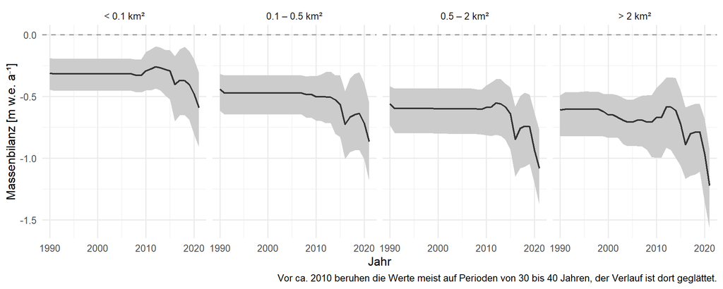

Abbildung 5: Ansatz 1: Massenbilanz im Zeitverlauf je Grössenklasse (Median und mittlere 50 % der Gletscher)

```r
# Jede Periode auf ihre Jahre verteilen, pro Gletscher und Jahr die kürzeste behalten
gl_jahre <- gl |>
  filter(!is.na(bgeod_mwe_a), jahr_end > jahr_start) |>
  select(sgi_id, jahr_start, jahr_end, periode_jahre, bgeod_mwe_a) |>
  mutate(jahr = map2(jahr_start, jahr_end - 1, seq)) |>
  unnest(jahr) |>
  group_by(sgi_id, jahr) |>
  slice_min(periode_jahre, n = 1, with_ties = FALSE) |>
  ungroup() |>
  left_join(klassen, by = "sgi_id")

# Jahre mit genügend Abdeckung
jahre_ok <- gl_jahre |>
  group_by(jahr) |>
  summarise(anteil = n_distinct(sgi_id) / n_total, .groups = "drop") |>
  filter(anteil >= 0.8) |>
  pull(jahr)

reihe_klasse <- gl_jahre |>
  filter(jahr %in% jahre_ok, !is.na(klasse)) |>
  group_by(klasse, jahr) |>
  summarise(
    n      = n(),
    median = median(bgeod_mwe_a),
    q25    = quantile(bgeod_mwe_a, 0.25),
    q75    = quantile(bgeod_mwe_a, 0.75),
    .groups = "drop"
  )

ggplot(reihe_klasse, aes(jahr, median)) +
  geom_hline(yintercept = 0, linetype = "dashed", colour = "grey60") +
  geom_ribbon(aes(ymin = q25, ymax = q75), fill = "grey80") +
  geom_line(colour = "grey20", linewidth = 0.8) +
  facet_wrap(~ klasse, nrow = 1) +
  labs(x = "Jahr", y = "Massenbilanz [m w.e. a⁻¹]",
       caption = "Vor ca. 2010 beruhen die Werte meist auf Perioden von 30 bis 40 Jahren, der Verlauf ist dort geglättet.")
```

**Was funktioniert hat:** Die Massenbilanz liegt in allen vier Klassen in jedem Jahr im negativen Bereich. Bis etwa 2010 sind die Linien praktisch flach, weil für die meisten Gletscher nur eine Periode von mehreren Jahrzehnten vorliegt (siehe Ansatz 3). Erst mit den kürzeren Perioden danach entsteht ein Verlauf. Der Median sinkt in der kleinsten Klasse von −0.31 (1990) auf −0.59 (2021) und in der grössten Klasse von −0.61 auf −1.22 m w.e. pro Jahr. Grössere Gletscher liegen insgesamt tiefer als kleine. Die Small Multiples mit gemeinsamer y-Achse machen beides direkt lesbar.

**Einschränkung:** Der Verlauf vor 2010 ist geglättet und sagt nichts über einzelne Jahre.

### 2.9.2 Ansatz 2: Gletschergrösse und Massenbilanz als Dichtekarte

**Frage:** Hängt die Massenbilanz mit der Gletschergrösse zusammen?

**Analytische Aufgabe:** Zusammenhang zwischen zwei numerischen Variablen.

**Marks und Channels:** Sechseckige Flächen (Hexbin) als Mark. Die Position zeigt Fläche (logarithmisch) und Massenbilanz, die Helligkeit der Sechsecke zeigt die Anzahl Gletscher. Die orange Linie ist eine geglättete Trendlinie.

Das einfache Streudiagramm aus der ersten Übersicht hat rund 1’400 Punkte, die sich im Bereich kleiner Gletscher stark überdecken. Die Dichtekarte macht sichtbar, wo die meisten Gletscher liegen.

**Code anzeigen**

[figure not shown]

Abbildung 6: Ansatz 2: Gletscherfläche (Start, logarithmisch) und Massenbilanz als Dichtekarte

```r
gl_lang |>
  filter(!is.na(area_start_km2)) |>
  ggplot(aes(area_start_km2, bgeod_mwe_a)) +
  geom_hline(yintercept = 0, linetype = "dashed", colour = "grey60") +
  geom_hex(bins = 30) +
  geom_smooth(method = "loess", formula = y ~ x, se = FALSE,
              colour = "#e08a2c", linewidth = 1) +
  scale_x_log10() +
  scale_fill_gradient(low = "grey90", high = "grey20") +
  labs(x = "Fläche am Start [km², logarithmisch]",
       y = "Massenbilanz [m w.e. a⁻¹]",
       fill = "Anzahl\nGletscher")
```

**Vorsicht bei der Deutung:** Jeder Gletscher ist mit seiner längsten Messperiode dargestellt. Diese Perioden sind unterschiedlich lang und liegen zu unterschiedlichen Zeiten, ein Teil der Unterschiede kann deshalb von der Periode statt von der Grösse kommen.

**Verworfen:** Das Streudiagramm aus der ersten Übersicht, weil sich die rund 1’400 Punkte im Bereich der kleinen Gletscher überdecken.

### 2.9.3 Ansatz 3: Messtermine aller Gletscher

**Frage:** Wann wurde welcher Gletscher gemessen, und wie dicht sind die Daten über die Zeit?

**Analytische Aufgabe:** Datenstruktur verstehen und Lücken erkennen.

**Marks und Channels:** Punkte (Messtermine) und Linien (erster bis letzter Termin). Die x-Position zeigt die Zeit, die y-Position ordnet jeden Gletscher in einer eigenen Zeile an, sortiert nach dem ersten Messtermin. Weil es 1’438 Gletscher sind, trägt die y-Achse keine Namen.

**Code anzeigen**

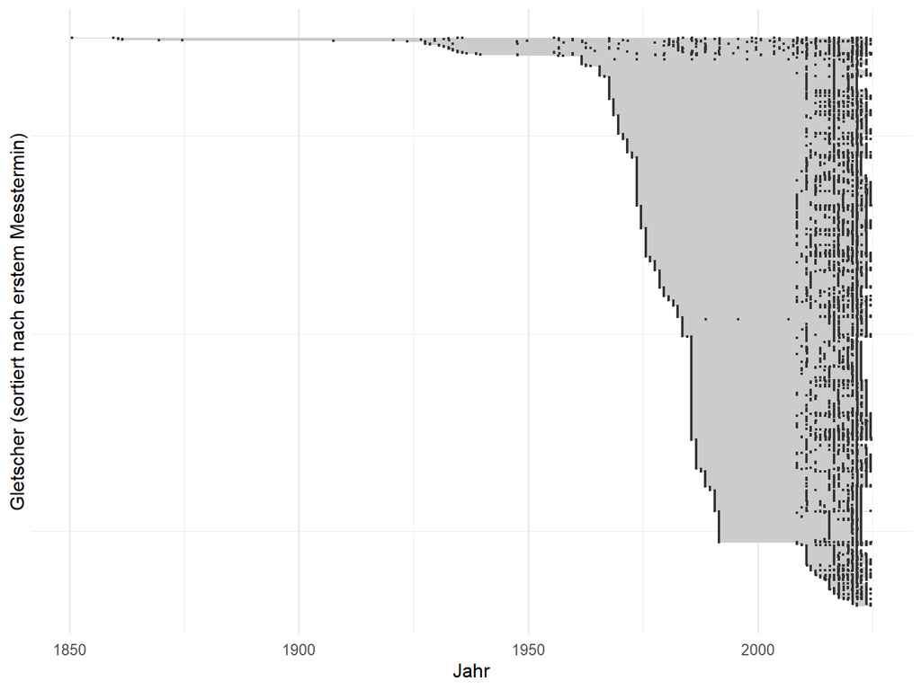

Abbildung 7: Ansatz 3: Messtermine aller Gletscher, sortiert nach erstem Termin (Datum teilweise geschätzt)

```r
termine <- bind_rows(
  gl |> select(sgi_id, datum = dt_start),
  gl |> select(sgi_id, datum = dt_end)
) |>
  distinct()

reihenfolge <- termine |>
  group_by(sgi_id) |>
  summarise(erster = min(datum), letzter = max(datum), .groups = "drop") |>
  arrange(erster, letzter) |>
  mutate(rang = row_number())

termine |>
  left_join(reihenfolge, by = "sgi_id") |>
  ggplot(aes(datum, rang)) +
  geom_segment(data = reihenfolge,
               aes(x = erster, xend = letzter, y = rang, yend = rang),
               colour = "grey80", linewidth = 0.2, inherit.aes = FALSE) +
  geom_point(size = 0.4, colour = "grey20") +
  scale_y_reverse() +
  labs(x = "Jahr", y = "Gletscher (sortiert nach erstem Messtermin)") +
  theme(axis.text.y = element_blank(), panel.grid.major.y = element_blank())
```

**Was funktioniert hat:** Die Grafik macht die Datenstruktur sofort sichtbar. Rund 1’150 der 1’438 Gletscher (etwa 80 %) wurden erstmals zwischen 1960 und 1989 gemessen, das ergibt die Treppe in der Mitte. Nur 47 Gletscher haben einen ersten Termin bis 1960. Ab etwa 2008 gibt es für fast alle Gletscher mehrere kurz aufeinanderfolgende Messungen. Dazwischen liegen nur wenige Termine. Das erklärt die flachen Linien in Ansatz 1 und zeigt, warum Aussagen zur Entwicklung vor 2010 nur grob möglich sind.

**Grenzen:** Die grauen Linien verschmelzen bei 1’438 Zeilen zu einer Fläche und zeigen deshalb nur den Zeitraum zwischen erstem und letztem Termin. Die eigentliche Information tragen die Punkte. Eine Darstellung für eine Stichprobe wäre lesbarer, würde aber das Gesamtbild verlieren.

### 2.9.4 Ansatz 4: Massenbilanz mit Unsicherheit für die grössten Gletscher

**Frage:** Wie verlässlich ist die Massenbilanz, und verlieren auch die grossen Gletscher sicher an Masse?

**Analytische Aufgabe:** Einzelne Werte vergleichen und ihre Unsicherheit beurteilen.

**Marks und Channels:** Punkte mit Fehlerbalken (± `sigma`). Die x-Position zeigt die Massenbilanz, die Gletscher stehen sortiert auf der y-Achse, die Punktgrösse zeigt die Dauer der Messperiode. Das Beispiel beschränkt sich auf die 15 grössten Gletscher, weil bei allen 1’438 die Fehlerbalken nicht mehr lesbar wären.

**Code anzeigen**

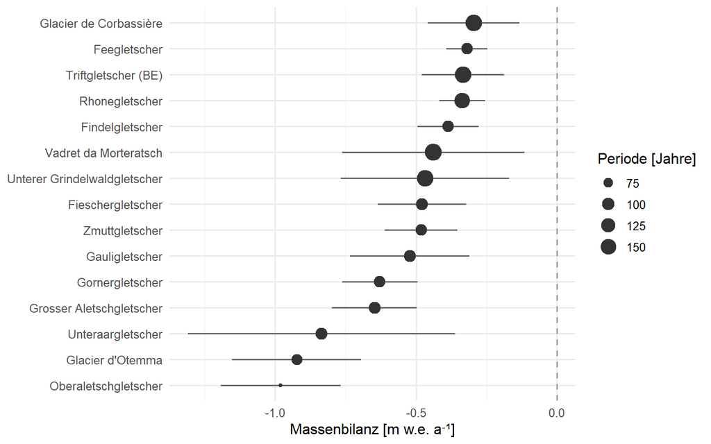

Abbildung 8: Ansatz 4: Massenbilanz mit Unsicherheit (± sigma) für die 15 grössten Gletscher (längste Periode)

```r
gl_lang |>
  slice_max(area_start_km2, n = 15, with_ties = FALSE) |>
  mutate(name = fct_reorder(name, bgeod_mwe_a)) |>
  ggplot(aes(bgeod_mwe_a, name)) +
  geom_vline(xintercept = 0, linetype = "dashed", colour = "grey60") +
  geom_linerange(aes(xmin = bgeod_mwe_a - sigma_mwe, xmax = bgeod_mwe_a + sigma_mwe),
                 orientation = "y", colour = "grey40") +
  geom_point(aes(size = periode_jahre), colour = "grey20") +
  labs(x = "Massenbilanz [m w.e. a⁻¹]", y = NULL, size = "Periode [Jahre]")
```

**Was funktioniert hat:** Bei allen 15 grössten Gletschern liegt der gesamte Unsicherheitsbereich im negativen Bereich, sie verlieren also sicher an Masse. Die Werte reichen von −0.30 (Glacier de Corbassière) bis −0.98 (Oberaletschgletscher). Die Unsicherheit ist sehr unterschiedlich: Der Unteraargletscher hat mit ±0.47 den breitesten Balken, Feegletscher und Rhonegletscher mit ±0.07 und ±0.08 die schmalsten. Die Punktgrösse zeigt, dass die Perioden zwischen 54 und 172 Jahren lang sind. Die fünf Gletscher mit Perioden über 145 Jahren haben alle eher moderate Werte (−0.30 bis −0.47).

**Vorsicht bei der Deutung:** Wegen der unterschiedlich langen Perioden sind die Gletscher nicht ganz vergleichbar. Der Balken zeigt ± `sigma`. Ob das einer Standardabweichung oder einem Konfidenzintervall entspricht, ist im Datensatz nicht beschrieben.

**Verworfen:** Fehlerbalken für alle 1’438 Gletscher, weil sie nicht mehr lesbar wären.

## 2.10 Zwischenfazit

Für die Frage nach der Entwicklung finde ich Ansatz 1 am aussagekräftigsten. Er zeigt den Trend und den Unterschied zwischen den Grössenklassen in einer einzigen Grafik. Ansatz 3 gehört als Begleitgrafik dazu, weil er erklärt, wie belastbar der Verlauf vor 2010 ist. Ansatz 2 ersetzt das einfache Streudiagramm. Ansatz 4 eignet sich als Ergänzung, wenn die Unsicherheit einzelner bekannter Gletscher thematisiert werden soll.

**Weiterverfolgen:** Ansatz 1 und Ansatz 3. **Verworfen:** Balken pro Jahr, das einfache Streudiagramm und Fehlerbalken für alle Gletscher.

**Offene Punkte:** Die Bedeutung der Buchstaben in der SGI-ID und die Legende der Quellkürzel sind zu klären. Zudem möchte ich prüfen, ob sich die Gletscher über die relative Flächenänderung (Prozent pro Jahr) besser vergleichen lassen.

## 2.11 Peer-Feedback und nächste Iteration

**Hinweis**

Wird nach der Vorlesung mit dem Feedback der anderen Studierenden ergänzt.